# results

Corinne

4/14/2021

The purpose of this script is to reproduce figures and numeric results for the paper “A Performance-Based Approach to Quantify Atmospheric River Flood Risk” (doi:XX). This file focuses on probabilistic results from running the entire PARRA framework in sequence for the lower Russian River in Sonoma County, California.

Please note: all figures are formatted for publication, therefore certain features may not display correctly in this markdown file.

```r
## setup information
source('_data/setup.R')
source('_data/plots.R')

## load required packages
require(units)

## load historic catalog
load('_data/catalog/catalog.Rdata')

## load location information
load('_data/lisflood/dem.Rdata')
load('_data/aoi/aoi.Rdata')
load('_data/NHD/NHD.Rdata')

## load NFIP claims & policies
load('D:/Research/_data/NFIP/NFIP.Rdata')
```

# 1 2019 Loss Results

We chose a particularly damaging AR event from 2019 as the case study. This decision is discussed further in the paper and in the `demonstration.Rmd` file.

## 1.1 Identify case study AR

```r
## identify 2019 case study AR event
casestudy <- catalog %>% filter(start_day == ymd('2019-02-25'))

## show the 2019 event variables as a formatted table
```

2019 Case Study AR Event

| Start Day | End Day | AR Category | Maximum IVT (kg/m/s) | Storm Duration (hrs) | Total Precipitation (mm) | Total Runoff (mm) | Peak Streamflow (m^3/s) | Time to Peak Streamflow (hrs) | Antecedent Soil Moisture (mm/m) |
| --- | --- | --- | --- | --- | --- | --- | --- | --- | --- |
| 2019-02-25 | 2019-02-27 | 3 | 620 | 57 | 208.39 | 106.03 | 1,129.84 | 40.87 | 139.98 |

## 1.2 Plot observed vs. simulated loss

We started with the real maximum IVT and duration from the 2019 event 10,000 and generated 10,000 probabilistic realizations of loss using Sherlock, Stanford’s high-performance computing cluster. All files associated with this calculation are stored in the `_results/2019event/` folder.

The dataframe *loss.sim* contains the probabilistic realization of total loss for each of the 10,000 simulations. Figure 9(a) compares the distribution of these probabilistic loss realizations to the true loss experienced by Sonoma County households as a result of the 2019 event.

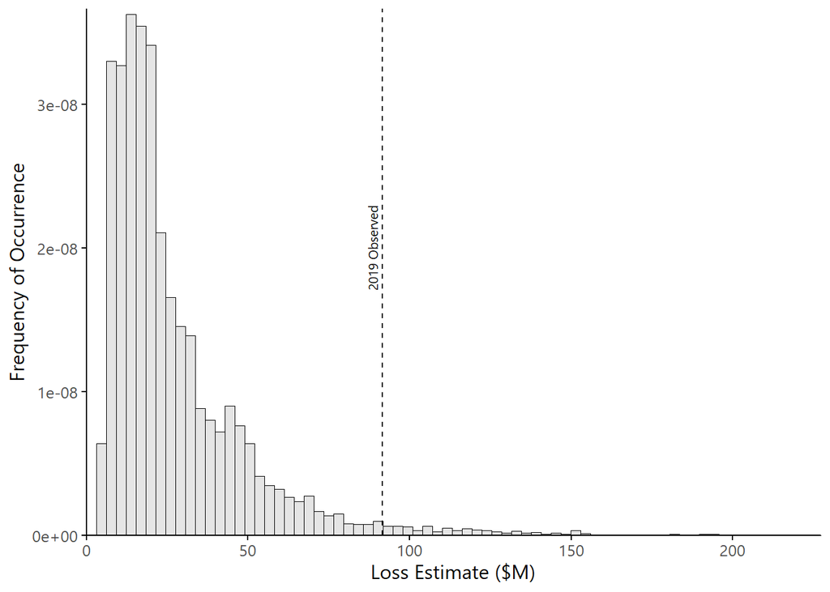

```r
## input observed residential loss for the 2019 event from news reports
loss.est <- 91.6e6

## load simulated loss from PARRA framework
load('_results/final/_results/event2019/DV.Rdata')

## plot figure 9(a): observed vs. simulated loss
```

## 1.3 Find the percentile of the observed loss within the simulated distribution

We can compare the simulated distribution to the observed value numerically as well as visually.

```r
## percentile
1 - (sum(loss.sim$loss > loss.est) / 1e4)

## maximum event
max(loss.sim$loss)/1e6
max(loss.sim$loss) / loss.est
```

```
## [1] 0.9777
## [1] 275.2795
## [1] 3.005234
```

## 1.4 Plot spatial distribution of simulated loss

The dataframe *loss.group* contains the average total loss aggregated by some spatial grouping, which in this case is census block groups. Figure 9(b) shows the expected spatial distribution of loss as predicted by the PARRA framework.

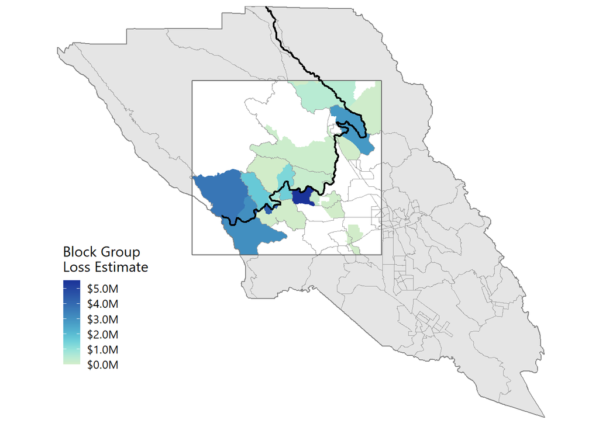

```r
## attach loss information to Sonoma County census block groups
sonoma_cbgs <- block_groups(state = 'CA', county = 'Sonoma') %>%
  mutate(group = toNumber(GEOID)) %>%
  left_join(loss.group %>% mutate(group = toNumber(group)), by = 'group') %>%
  mutate(loss = ifelse(is.na(loss), 0, loss)) %>%
  st_transform(6417) %>%
  st_crop(aoi)

## plot figure 9(b): spatial distribution of simulated loss
```

# 2 Average Annual Loss (AAL)

We move now from examining the 2019 event to incorporating the full historic catalog into our analysis. This captures the full character of AR-induced fluvial flood risk in the lower Russian River study area. We generate 100 realizations of loss for each of the 382 events in the historic catalog. This creates a 3200-year synthetic record. We refer the user to the paper for a more in-depth discussion of the generation of this stochastic record.

## 2.1 Calculate AAL based on NFIP claims

The flood AAL for the study area is a number subject to significant uncertainty. Here we provide one estimate of that number from an independent source: flood insurance claims from the National Flood Insurance Program (NFIP). We first find the average annual insured losses from the census tracts within the study area. We estimate insurance penetration rate by dividing the number of NFIP policies by the number of households, then scale the average annual insured losses by this penetration rate to estimate total AAL for all households. The resulting number is reported in 2019 dollars.

```r
## find the average annual insured losses from claims data
inflation <- read.csv('C:/Users/cbowers/Desktop/inflation2019.csv', header = FALSE) %>%
  setNames(c('year', 'rate'))
aal.claims <- claims %>%
  mutate(year = year(dateofloss)) %>%
  left_join(inflation, by = 'year') %>%
  mutate(buildingclaim_2018 = amountpaidonbuildingclaim * rate,
         contentsclaim_2018 = amountpaidoncontentsclaim * rate) %>%
  right_join(sonoma[aoi,] %>% st_drop_geometry %>% transmute(censustract = toNumber(GEOID))) %>%
  mutate(wateryear = year(dateofloss + months(3))) %>%
  group_by(wateryear) %>%
  summarize(min = min(dateofloss),
            max = max(dateofloss),
            structureloss = Sum(buildingclaim_2018),
            contentsloss = Sum(contentsclaim_2018),
            totalloss = structureloss + contentsloss) %>%
  filter(wateryear > 1978 & wateryear < 2019 & !is.na(wateryear)) %>%
  summarize(loss = sum(totalloss)/40) %>% .$loss

## find the number of policies per year in the study area
insurancepolicies <- policies %>%
  right_join(sonoma[aoi,] %>% st_drop_geometry %>% transmute(censustract = toNumber(GEOID))) %>%
  mutate(wateryear = year(ymd(policyeffectivedate) + months(3))) %>%
  group_by(wateryear) %>%
  summarize(min = min(ymd(policyeffectivedate)),
            max = max(ymd(policyeffectivedate)),
            n = length(policyeffectivedate)) %>%
  filter(wateryear > 2009 & wateryear < 2020 & !is.na(wateryear)) %>%
  summarize(avg = mean(n)) %>% .$avg

## find the number of residences per year in the study area
profile_vars <- listCensusMetadata(name = 'acs/acs5/profile', vintage = 2018)
housingunits <-
  getCensus(name = 'acs/acs5/profile', vars = 'group(DP04)', vintage = 2018,
            regionin = 'state:06+county:097', region = 'tract:*') %>%
  select(-state, -GEO_ID, -NAME) %>%
  select(-ends_with('M'), -ends_with('A'), -ends_with('PE')) %>%
  pivot_longer(cols = ends_with('E'), names_to = 'variable', values_to = 'estimate') %>%
  left_join(profile_vars %>% select('name', 'label'), by = c('variable' = 'name')) %>%
  mutate(censustract = 6*1e9 + toNumber(county)*1e6 + toNumber(tract)) %>%
  right_join(sonoma[aoi,] %>% st_drop_geometry %>% transmute(censustract = toNumber(GEOID))) %>%
  group_by(variable, label) %>%
  summarize(estimate = sum(estimate)) %>%
  separate(label, c(NA, 'group_title', 'group', 'description'), sep = '!!', fill = 'right') %>%
  filter(variable == 'DP04_0001E') %>% .$estimate

## find the insurance penetration rate
penetration <- insurancepolicies/housingunits

## find the average annual loss
aal.claims/penetration / 1e6
```

```
## [1] 101.6007
```